# 머신러닝 과제 3

## 201724557 장수현

# 1. 딥러닝 개발환경 (Development Environment)

딥러닝 개발을 위한 나의 개발환경은 다음과 같다.

### PC

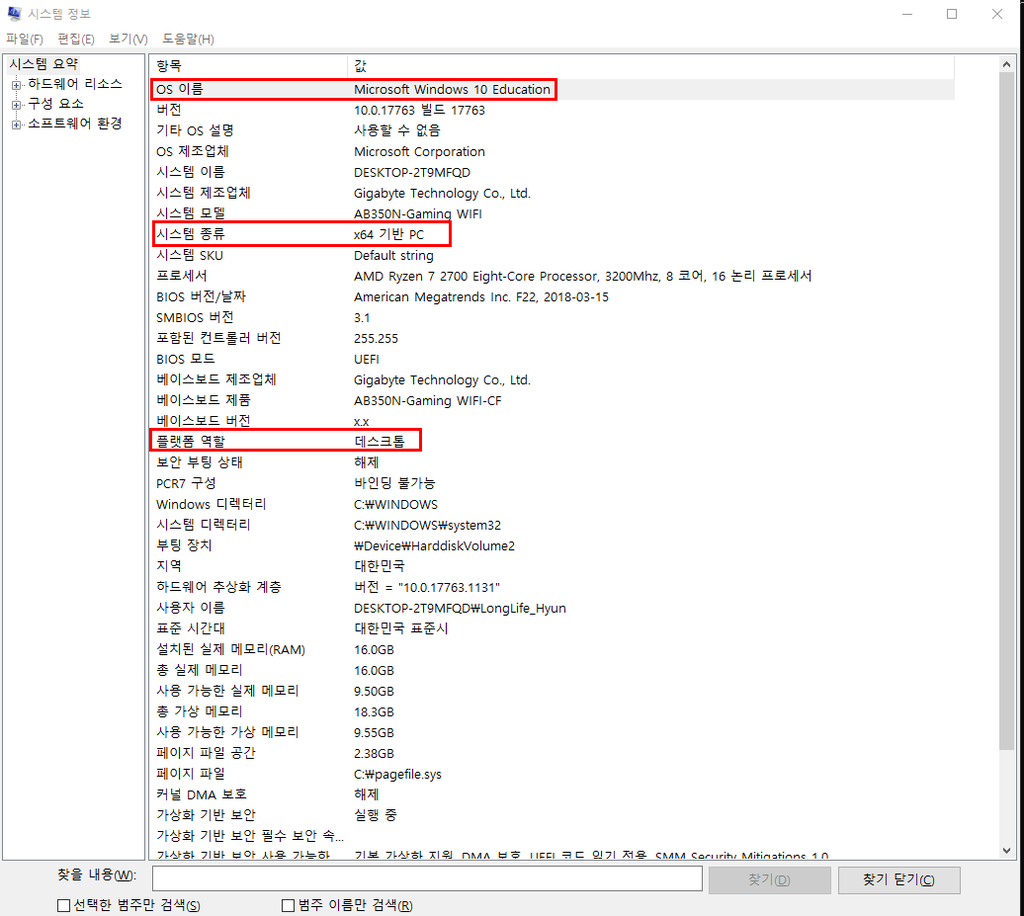

PC : 64비트 기반 데스크탑  
OS : MS Windows 10 Education

### jupyter notebook & Python & Tensorflow

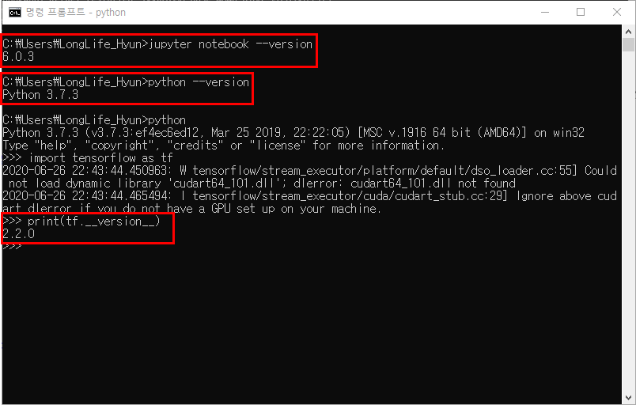

### jupyter notebook 실행 화면

[figure not shown]

### 기타

원래는 Docker for Window로 개발 환경을 구축하려 했다. 그러나 graphviz path관련 오류를 해결하지 못하여 결국 windows 환경에서 과제를 진행하게 되었다.

[figure not shown]

# 2. 모델 생성 (Making Models)

## tensorflow 불러오기

`import tensorflow as tf`를 사용하여 tensorflow를 tf로 사용한다.(파이썬 문법)  
tensorflow 중에서 **keras**를 사용하여 모델을 만들어 보겠다.

```python
import tensorflow as tf
from tensorflow.keras import Input, Model
from tensorflow.keras.layers import *
```

## Python을 사용하는데 필요한 라이브러리 호출하기

```python
import numpy as np
import matplotlib.pyplot as plt
import matplotlib.image as mpimg
```

## MNIST - 사람의 손글씨를 모아 놓은 데이터

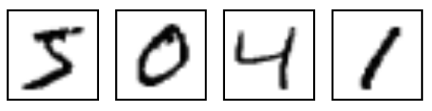

훈련 데이터 6만개, 테스트 데이터 1만개로 구성되어 있으며 tensorflow의 내장 함수를 사용하여 쉽게 불러올 수 있다.  
각 데이터는 2차원의 이미지 형태 이며, 가로 28픽셀 세로 28픽셀로 28x28데이터 이다.  
각 데이터 포인트는 0~255사이 값을 가지고 있다.

```python
mnist = tf.keras.datasets.mnist
```

```python
(x_train, y_train), (x_test, y_test) = mnist.load_data()
x_train, x_test = x_train / 255.0, x_test / 255.0
```

Deep learning을 할 때 데이터가 0~1 사이의 값을 가지는 것이 학습이 잘된다.  
따라서 학습 데이터를 최대값 255로 나누어서 0~1 사이 값을 가지도록 만든다.

## CNN 사용하여 모델 만들기

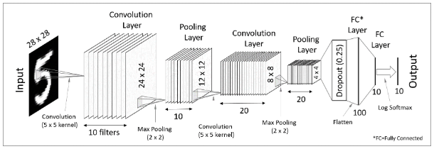

CNN 모델은 2차원 데이터는 2차원 형태로 분석하고자 하는 것이다.  
과거 이미지 처리에서 사용한 mask를 사용하여 이미지를 분석하던 것과 비슷한 방법이다.

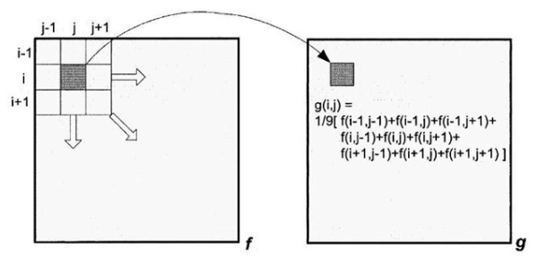

CNN은 이 mask를 deep learning을 사용하여 학습해 보는 것이다.

### 데이터 변환

먼저 CNN을 사용하기 위해서는 3차원 데이터 형태로 만들어야 한다.  
2차원으로 각 데이터의 위치를 지정해주고 데이터의 값 차원을 추가해서 총 3차원으로 만든다.

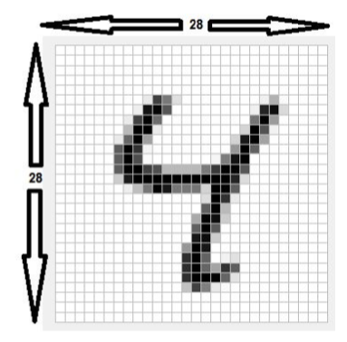

```python
train_img = x_train.reshape((-1,28,28,1))
test_img = x_test.reshape((-1,28,28,1))
```

### CNN 모델 생성

**CNN layer + MaxPooling layer + Dropout layer**를 1개의 셋트로 총 2개 만들고  
최종 결과를 출력하기 위해서 Flatten layer와 Dense layer를 통해 판별한다.

### Case1 : Dropout = 0.1

```python
CNN_input = Input(shape = (28,28,1))
CNN = Conv2D(57,(3,3),activation='relu')(CNN_input)
CNN = MaxPool2D((2,2))(CNN)
CNN = Dropout(0.1)(CNN)
CNN = Conv2D(114,(3,3),activation='relu')(CNN)
CNN = MaxPool2D((2,2))(CNN)
CNN = Dropout(0.1)(CNN)
CNN = Flatten()(CNN)
CNN = Dense(10,activation='softmax')(CNN)
CNN_model = Model(CNN_input,CNN)
CNN_model.summary()
```

```
Model: "model"
_________________________________________________________________
Layer (type)                 Output Shape              Param #
=================================================================
input_1 (InputLayer)         [(None, 28, 28, 1)]       0
_________________________________________________________________
conv2d (Conv2D)              (None, 26, 26, 57)        570
_________________________________________________________________
max_pooling2d (MaxPooling2D) (None, 13, 13, 57)        0
_________________________________________________________________
dropout (Dropout)            (None, 13, 13, 57)        0
_________________________________________________________________
conv2d_1 (Conv2D)            (None, 11, 11, 114)       58596
_________________________________________________________________
max_pooling2d_1 (MaxPooling2 (None, 5, 5, 114)         0
_________________________________________________________________
dropout_1 (Dropout)          (None, 5, 5, 114)         0
_________________________________________________________________
flatten (Flatten)            (None, 2850)              0
_________________________________________________________________
dense (Dense)                (None, 10)                28510
=================================================================
Total params: 87,676
Trainable params: 87,676
Non-trainable params: 0
_________________________________________________________________
```

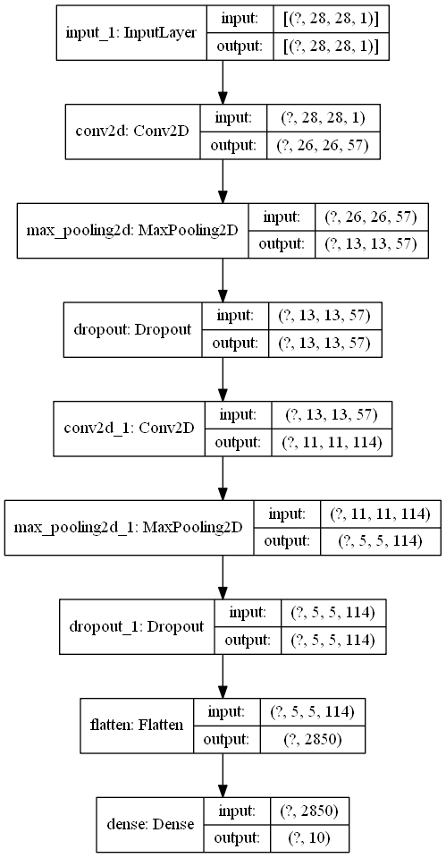

```python
tf.keras.utils.plot_model(CNN_model, show_shapes=True)
```

```python
CNN_model.compile(optimizer='adam',
              loss='sparse_categorical_crossentropy',
              metrics=['accuracy'])
CNN_model.fit(train_img,y_train, epochs=5)
```

```
<tensorflow.python.keras.callbacks.History at 0x29ff9de1a58>
```

```python
CNN_model.evaluate(test_img,  y_test, verbose=2)
```

```
313/313 - 2s - loss: 0.0270 - accuracy: 0.9909
```

```
[0.027023665606975555, 0.9908999800682068]
```

### Case2 : Dropout = 0.4

```python
CNN_input = Input(shape = (28,28,1))
CNN = Conv2D(57,(3,3),activation='relu')(CNN_input)
CNN = MaxPool2D((2,2))(CNN)
CNN = Dropout(0.4)(CNN)
CNN = Conv2D(114,(3,3),activation='relu')(CNN)
CNN = MaxPool2D((2,2))(CNN)
CNN = Dropout(0.4)(CNN)
CNN = Flatten()(CNN)
CNN = Dense(10,activation='softmax')(CNN)
CNN_model = Model(CNN_input,CNN)
CNN_model.summary()
```

```
Model: "model_1"
_________________________________________________________________
Layer (type)                 Output Shape              Param #
=================================================================
input_2 (InputLayer)         [(None, 28, 28, 1)]       0
_________________________________________________________________
conv2d_2 (Conv2D)            (None, 26, 26, 57)        570
_________________________________________________________________
max_pooling2d_2 (MaxPooling2 (None, 13, 13, 57)        0
_________________________________________________________________
dropout_2 (Dropout)          (None, 13, 13, 57)        0
_________________________________________________________________
conv2d_3 (Conv2D)            (None, 11, 11, 114)       58596
_________________________________________________________________
max_pooling2d_3 (MaxPooling2 (None, 5, 5, 114)         0
_________________________________________________________________
dropout_3 (Dropout)          (None, 5, 5, 114)         0
_________________________________________________________________
flatten_1 (Flatten)          (None, 2850)              0
_________________________________________________________________
dense_1 (Dense)              (None, 10)                28510
=================================================================
Total params: 87,676
Trainable params: 87,676
Non-trainable params: 0
_________________________________________________________________
```

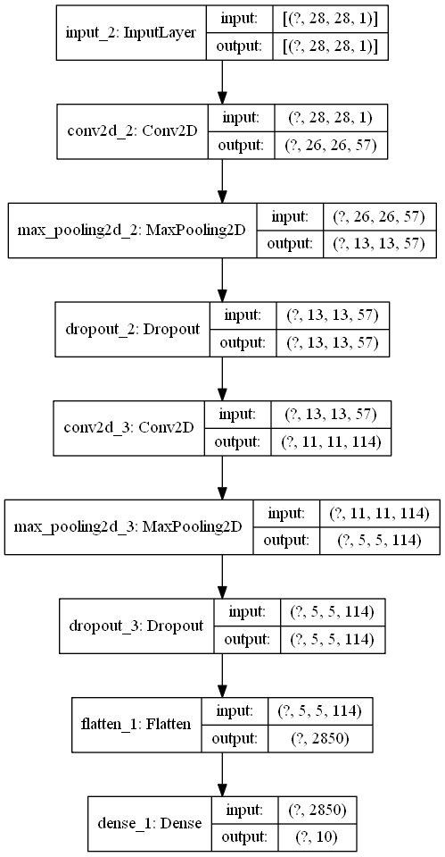

```python
tf.keras.utils.plot_model(CNN_model, show_shapes=True)
```

```python
CNN_model.compile(optimizer='adam',
              loss='sparse_categorical_crossentropy',
              metrics=['accuracy'])
CNN_model.fit(train_img,y_train, epochs=5)
```

```
<tensorflow.python.keras.callbacks.History at 0x29ffb0b3208>
```

```python
CNN_model.evaluate(test_img,  y_test, verbose=2)
```

```
313/313 - 2s - loss: 0.0315 - accuracy: 0.9890
```

```
[0.03151492029428482, 0.9890000224113464]
```

### Case3 : Dropout = 0.9

```python
CNN_input = Input(shape = (28,28,1))
CNN = Conv2D(57,(3,3),activation='relu')(CNN_input)
CNN = MaxPool2D((2,2))(CNN)
CNN = Dropout(0.9)(CNN)
CNN = Conv2D(114,(3,3),activation='relu')(CNN)
CNN = MaxPool2D((2,2))(CNN)
CNN = Dropout(0.9)(CNN)
CNN = Flatten()(CNN)
CNN = Dense(10,activation='softmax')(CNN)
CNN_model = Model(CNN_input,CNN)
CNN_model.summary()
```

```
Model: "model_2"
_________________________________________________________________
Layer (type)                 Output Shape              Param #
=================================================================
input_3 (InputLayer)         [(None, 28, 28, 1)]       0
_________________________________________________________________
conv2d_4 (Conv2D)            (None, 26, 26, 57)        570
_________________________________________________________________
max_pooling2d_4 (MaxPooling2 (None, 13, 13, 57)        0
_________________________________________________________________
dropout_4 (Dropout)          (None, 13, 13, 57)        0
_________________________________________________________________
conv2d_5 (Conv2D)            (None, 11, 11, 114)       58596
_________________________________________________________________
max_pooling2d_5 (MaxPooling2 (None, 5, 5, 114)         0
_________________________________________________________________
dropout_5 (Dropout)          (None, 5, 5, 114)         0
_________________________________________________________________
flatten_2 (Flatten)          (None, 2850)              0
_________________________________________________________________
dense_2 (Dense)              (None, 10)                28510
=================================================================
Total params: 87,676
Trainable params: 87,676
Non-trainable params: 0
_________________________________________________________________
```

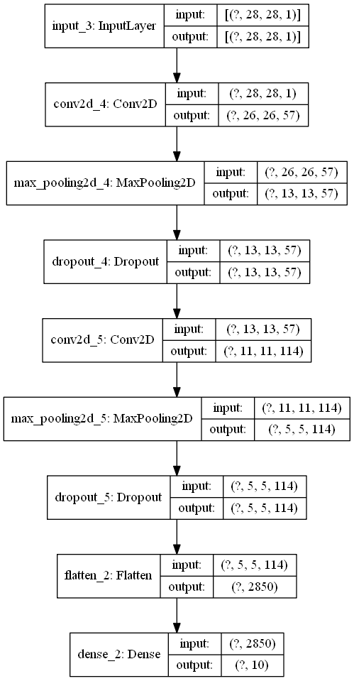

```python
tf.keras.utils.plot_model(CNN_model, show_shapes=True)
```

```python
CNN_model.compile(optimizer='adam',
              loss='sparse_categorical_crossentropy',
              metrics=['accuracy'])
CNN_model.fit(train_img,y_train, epochs=5)
```

```
<tensorflow.python.keras.callbacks.History at 0x29ffb1b5198>
```

```python
CNN_model.evaluate(test_img,  y_test, verbose=2)
```

```
313/313 - 2s - loss: 0.1785 - accuracy: 0.9676
```

```
[0.17854127287864685, 0.9675999879837036]
```

### Case4 : Dropout = 0.99

```python
CNN_input = Input(shape = (28,28,1))
CNN = Conv2D(57,(3,3),activation='relu')(CNN_input)
CNN = MaxPool2D((2,2))(CNN)
CNN = Dropout(0.99)(CNN)
CNN = Conv2D(114,(3,3),activation='relu')(CNN)
CNN = MaxPool2D((2,2))(CNN)
CNN = Dropout(0.99)(CNN)
CNN = Flatten()(CNN)
CNN = Dense(10,activation='softmax')(CNN)
CNN_model = Model(CNN_input,CNN)
CNN_model.summary()
```

```
Model: "model_3"
_________________________________________________________________
Layer (type)                 Output Shape              Param #
=================================================================
input_4 (InputLayer)         [(None, 28, 28, 1)]       0
_________________________________________________________________
conv2d_6 (Conv2D)            (None, 26, 26, 57)        570
_________________________________________________________________
max_pooling2d_6 (MaxPooling2 (None, 13, 13, 57)        0
_________________________________________________________________
dropout_6 (Dropout)          (None, 13, 13, 57)        0
_________________________________________________________________
conv2d_7 (Conv2D)            (None, 11, 11, 114)       58596
_________________________________________________________________
max_pooling2d_7 (MaxPooling2 (None, 5, 5, 114)         0
_________________________________________________________________
dropout_7 (Dropout)          (None, 5, 5, 114)         0
_________________________________________________________________
flatten_3 (Flatten)          (None, 2850)              0
_________________________________________________________________
dense_3 (Dense)              (None, 10)                28510
=================================================================
Total params: 87,676
Trainable params: 87,676
Non-trainable params: 0
_________________________________________________________________
```

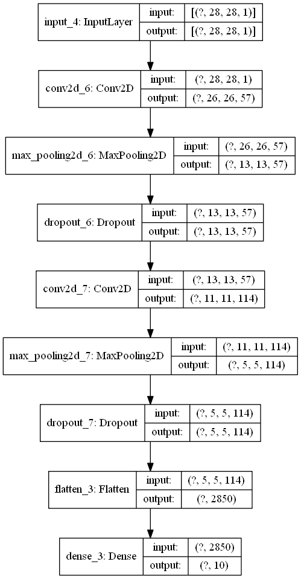

```python
tf.keras.utils.plot_model(CNN_model, show_shapes=True)
```

```python
CNN_model.compile(optimizer='adam',
              loss='sparse_categorical_crossentropy',
              metrics=['accuracy'])
CNN_model.fit(train_img,y_train, epochs=5)
```

```
<tensorflow.python.keras.callbacks.History at 0x29ffb38aa90>
```

```python
CNN_model.evaluate(test_img,  y_test, verbose=2)
```

```
313/313 - 2s - loss: 2.3011 - accuracy: 0.1135
```

```
[2.3011062145233154, 0.11349999904632568]
```

### Case5 : Dropout = 0.95

```python
CNN_input = Input(shape = (28,28,1))
CNN = Conv2D(57,(3,3),activation='relu')(CNN_input)
CNN = MaxPool2D((2,2))(CNN)
CNN = Dropout(0.95)(CNN)
CNN = Conv2D(114,(3,3),activation='relu')(CNN)
CNN = MaxPool2D((2,2))(CNN)
CNN = Dropout(0.95)(CNN)
CNN = Flatten()(CNN)
CNN = Dense(10,activation='softmax')(CNN)
CNN_model = Model(CNN_input,CNN)
CNN_model.summary()
```

```
Model: "model_4"
_________________________________________________________________
Layer (type)                 Output Shape              Param #
=================================================================
input_5 (InputLayer)         [(None, 28, 28, 1)]       0
_________________________________________________________________
conv2d_8 (Conv2D)            (None, 26, 26, 57)        570
_________________________________________________________________
max_pooling2d_8 (MaxPooling2 (None, 13, 13, 57)        0
_________________________________________________________________
dropout_8 (Dropout)          (None, 13, 13, 57)        0
_________________________________________________________________
conv2d_9 (Conv2D)            (None, 11, 11, 114)       58596
_________________________________________________________________
max_pooling2d_9 (MaxPooling2 (None, 5, 5, 114)         0
_________________________________________________________________
dropout_9 (Dropout)          (None, 5, 5, 114)         0
_________________________________________________________________
flatten_4 (Flatten)          (None, 2850)              0
_________________________________________________________________
dense_4 (Dense)              (None, 10)                28510
=================================================================
Total params: 87,676
Trainable params: 87,676
Non-trainable params: 0
_________________________________________________________________
```

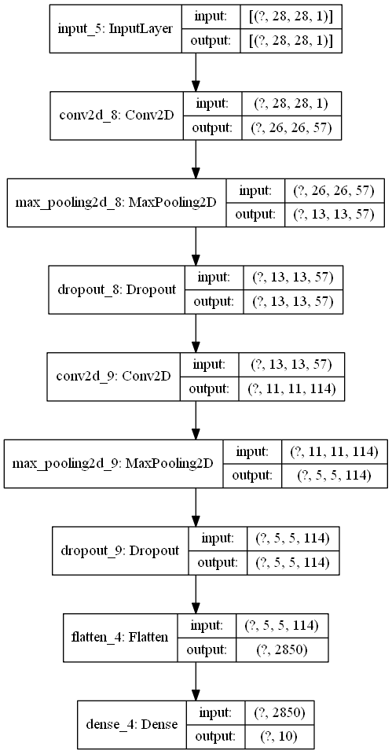

```python
tf.keras.utils.plot_model(CNN_model, show_shapes=True)
```

```python
CNN_model.compile(optimizer='adam',
              loss='sparse_categorical_crossentropy',
              metrics=['accuracy'])
CNN_model.fit(train_img,y_train, epochs=5)
```

```
<tensorflow.python.keras.callbacks.History at 0x29ff9dc0e48>
```

```python
CNN_model.evaluate(test_img,  y_test, verbose=2)
```

```
313/313 - 2s - loss: 0.4982 - accuracy: 0.9088
```

```
[0.498157799243927, 0.9088000059127808]
```

### Case6 : Dropout = 0.96

```python
CNN_input = Input(shape = (28,28,1))
CNN = Conv2D(57,(3,3),activation='relu')(CNN_input)
CNN = MaxPool2D((2,2))(CNN)
CNN = Dropout(0.96)(CNN)
CNN = Conv2D(114,(3,3),activation='relu')(CNN)
CNN = MaxPool2D((2,2))(CNN)
CNN = Dropout(0.96)(CNN)
CNN = Flatten()(CNN)
CNN = Dense(10,activation='softmax')(CNN)
CNN_model = Model(CNN_input,CNN)
CNN_model.summary()
```

```
Model: "model_5"
_________________________________________________________________
Layer (type)                 Output Shape              Param #
=================================================================
input_6 (InputLayer)         [(None, 28, 28, 1)]       0
_________________________________________________________________
conv2d_10 (Conv2D)           (None, 26, 26, 57)        570
_________________________________________________________________
max_pooling2d_10 (MaxPooling (None, 13, 13, 57)        0
_________________________________________________________________
dropout_10 (Dropout)         (None, 13, 13, 57)        0
_________________________________________________________________
conv2d_11 (Conv2D)           (None, 11, 11, 114)       58596
_________________________________________________________________
max_pooling2d_11 (MaxPooling (None, 5, 5, 114)         0
_________________________________________________________________
dropout_11 (Dropout)         (None, 5, 5, 114)         0
_________________________________________________________________
flatten_5 (Flatten)          (None, 2850)              0
_________________________________________________________________
dense_5 (Dense)              (None, 10)                28510
=================================================================
Total params: 87,676
Trainable params: 87,676
Non-trainable params: 0
_________________________________________________________________
```

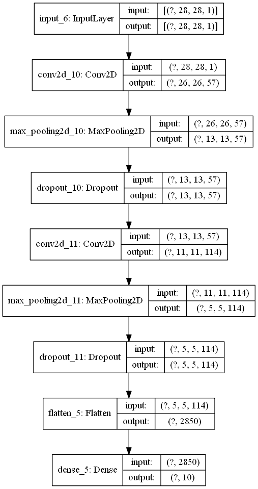

```python
tf.keras.utils.plot_model(CNN_model, show_shapes=True)
```

```python
CNN_model.compile(optimizer='adam',
              loss='sparse_categorical_crossentropy',
              metrics=['accuracy'])
CNN_model.fit(train_img,y_train, epochs=5)
```

```
<tensorflow.python.keras.callbacks.History at 0x29fa567bf60>
```

```python
CNN_model.evaluate(test_img,  y_test, verbose=2)
```

```
313/313 - 2s - loss: 1.4124 - accuracy: 0.4810
```

```
[1.4123649597167969, 0.48100000619888306]
```

# 3. 결과

CNN모델 생성 및 학습 결과는 다음과 같다.

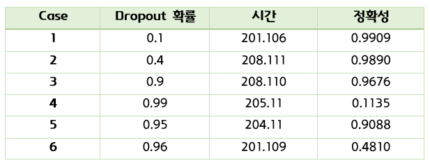

의외로 시간은 Dropout, 정확성과 연관이 떨어졌다. 정확성과 반비례할 것이라는 예측과는 달랐는데 정말 연관이 없다기 보다는 예제로 학습한 데이터가 매우 작았기 때문일 것이라 추측한다.